[figure not shown]

# Machine Learning

In this section, we train a machine learning with the goal of being able to predict adverse events from tweets. In a second step, we apply this machine learning to recent twitter data. The question we ask here is the following:

> If we train a model for predicting adverse drug reaction from Twitter data generated in 2013, are the results still valid nowadays?

This question is of critical importance to the research program initiated by the papers mentioned in our text: if the language in social media changes so drastically over few years that models trained on old data are not valid anymore, this means that experts have to annotate quite large amounts of tweets on a regular basis to have valid training samples.

A more refined version of the question above is:

> Is the quantitative measure “auc” when the model is evaluated on recent data significantly lower than on the validation set used in the original studies?

## Data

The dataset was prepared in the Data Cleaning section. Here, we combine the various datasets and split into a training and validation set:

- The dataset from [Nikfarjam et al] comes split into a training and a test set. We use this splitting.
- The binary annotated dataset from [Abeed Sarker and Graciela Gonzalez] is split into a training (75%) and cross-validation (25%) set

The reason for actually splitting the dataset at this stage and not just performing repeated cross validation is that we will train **several models** on the training data and then [use the scores of these models as **inputs** to a new machine learning model](http://www.stat.berkeley.edu/~ledell/docs/dlab_ensembles.pdf).

Actually, to perform proper cross validation we should repeat this entire procedure several times.

```r
tidy_data <- function() {
    # Prepares two tidy datasets: training set and test set
    #
    # Args: None
    #
    # Returns: list whose first entry is the training set and whose second
    #          entry is the test set

    # Load datasets
    load("../data/cleaned_train.Rda")
    load("../data/cleaned_test.Rda")
    load("../data/cleaned_binary.Rda")

    train_data_annotated <-
    cleaned_train %>%
    mutate(is_AE = as.factor(ifelse(!is.na(start_offset), "Yes", "No")))

    test_data_annotated <-
    cleaned_test %>%
    mutate(is_AE = as.factor(ifelse(!is.na(start_offset), "Yes", "No")))

    # Read binary annotated dataset
    binary_data <- cleaned_binary
    binary_train_ind <- createDataPartition(binary_data$is_AE, p = 0.75, list = FALSE)

    # Bind two sets
    train_data <-
    bind_rows(train_data_annotated,
    binary_data %>% slice(binary_train_ind)
    ) %>%
    select(tweet_id, user_id, stemmed, positive,
    negative, hashtag, URL, drug, is_AE) %>%
    distinct(tweet_id)

    test_data <-
    bind_rows(test_data_annotated,
    binary_data %>% slice(-binary_train_ind)
    )  %>%
    select(tweet_id, user_id, stemmed, positive,
    negative, hashtag, URL, drug, is_AE)

    # Convert to factor
    train_data$is_AE %<>% as.factor
    test_data$is_AE %<>% as.factor

    # Distinct tweet texts to avoid overfitting
    train_data %<>% distinct(stemmed)
    test_data %<>% distinct(stemmed)

    list(train = train_data, test = test_data)
    }

    data <- tidy_data()
```

The dataset consists at this stage of the following features:

| Column name | Description |
| --- | --- |
| tweet_id | Unique identifier of the tweet |
| user_id | Unique identifier of the user posting the tweet |
| stemmed | Actual tweet text, cleaned and stemmed |
| positive | Positive sentiments |
| negative | Negative sentiments |
| hastag | character of hashtags |
| URL | does the tweet contain a URLS |
| drug | drug names |
| is_AE | Is the tweet related to an adverse event |

## Exploratory data analysis

Let us first do exploratory data analysis on the tweets.

The first interesting question we have is how **balanced** the dataset is: what is the proportion of adverse event related tweets?

```r
data[[1]] %$%
    table(is_AE) %>%
    pander
```

| No | Yes |
| --- | --- |
| 2689 | 615 |

So there is quite a big imbalance: most tweets containing one of the drug names are not related to an adverse event.

One very popular method for EDA in text mining is to use **wordclouds**. We first produce two wordclouds: one (in black) with tweets not related to an AE and one (in green) related to adverse events. We see that there are interesting differences between the two wordclouds.

- The right one contains many more “negative” words and words that are obviously related to not feeling well
- The left wordcloud contains many neutral words, but also many negative words. These negative words, however are not related to an adverse event (consider, e.g. the tweet “depression hurts cymbalta can help”)

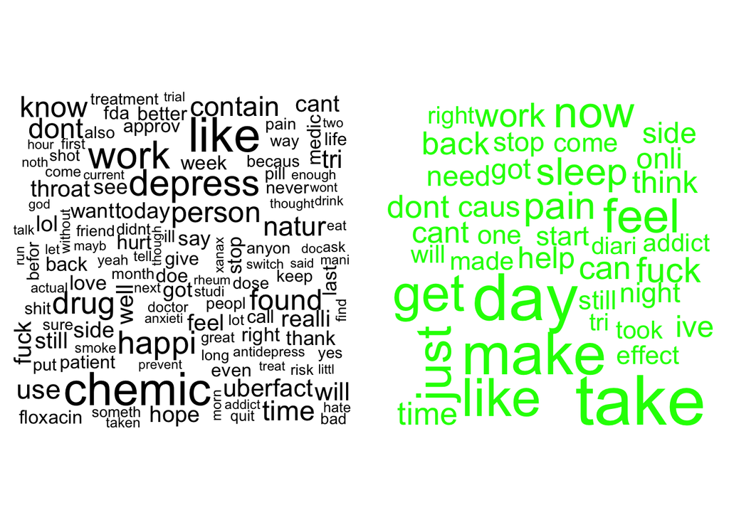

```r
par(mfrow = c(1, 2))
    wordcloud(data[["train"]] %>% filter(is_AE == "No") %$% stemmed,
    min.freq = 20,
    random.color = TRUE,
    colors = "black"
    )

    wordcloud(data[["train"]] %>% filter(is_AE == "Yes") %$% stemmed,
    min.freq = 20,
    random.color = TRUE,
    colors = "green"
    )
```

Next, we show the 30 most frequent words, both for tweets related to ADRs and tweets not related to ADRs.

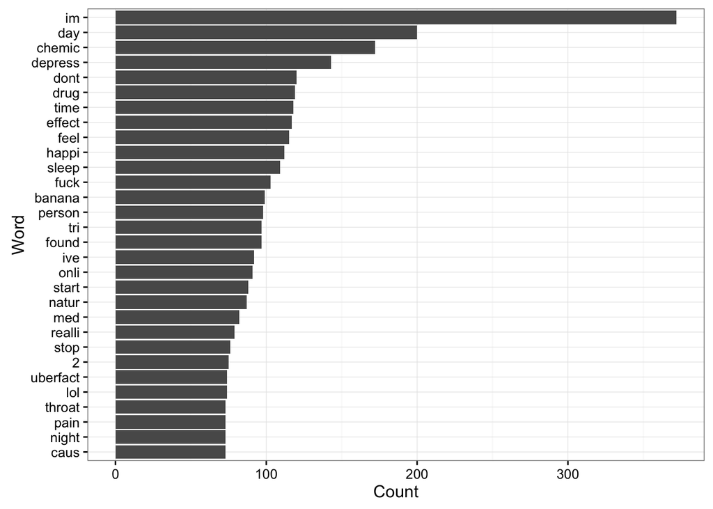

```r
data[[1]] %>%
    unnest_tokens(word, stemmed) %>%
    anti_join(stop_words, by = "word") %>%
    count(word) %>%
    top_n(30, n) %>%
    mutate(word = reorder(word, n)) %>%
    ggplot(aes(x = word, y = n)) +
    geom_bar(stat = "identity") +
    coord_flip() +
    xlab("Word") +
    ylab("Count")
```

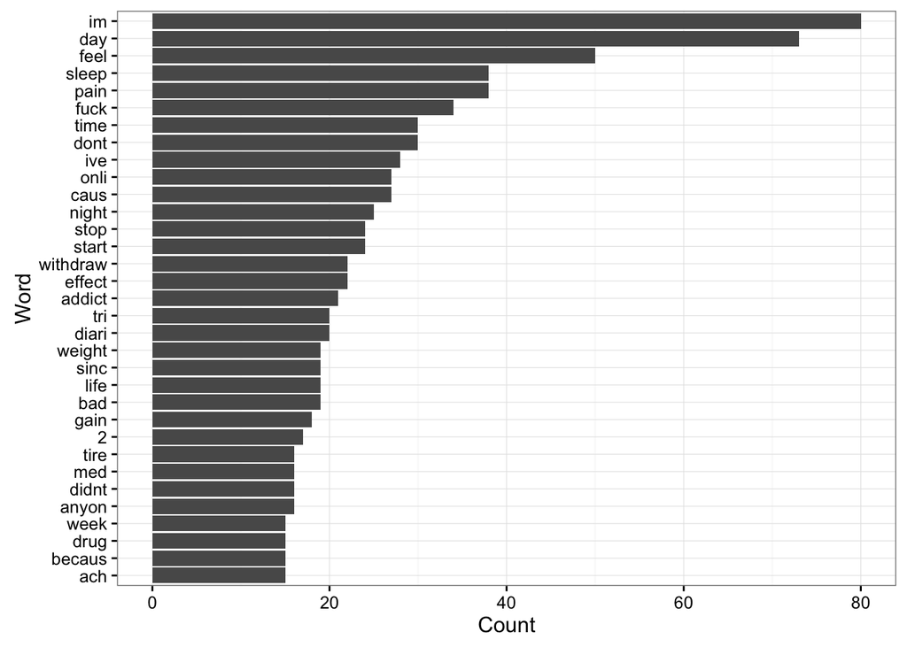

```r
data[[1]] %>%
    unnest_tokens(word, stemmed) %>%
    anti_join(stop_words, by = "word") %>%
    filter(is_AE == "Yes") %>%
    count(word) %>%
    top_n(30, n) %>%
    ungroup() %>%
    mutate(word = reorder(word, n)) %>%
    ggplot(aes(x = word, y = n)) +
    geom_bar(stat = "identity") +
    coord_flip() +
    xlab("Word") +
    ylab("Count")
```

Next, we take the `sentiments` data from the `tidytext` package to do sentiment analysis (we add these sentiments in addition to the ones mentioned in the data cleaning section, because they give a more refined picture of sentiments, and not only positive and negative). We see quite a big difference in sentiments between tweets corresponding to adverse events and those not corresponding to adverse events:

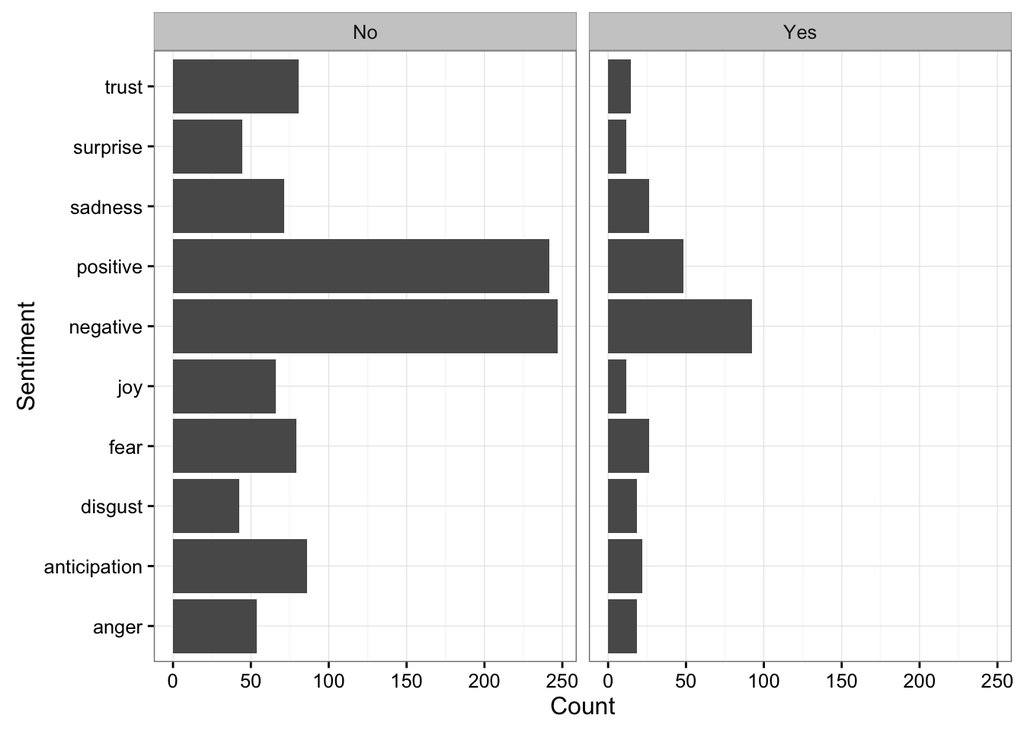

```r
data[[1]] %>%
    unnest_tokens(word, stemmed) %>%
    inner_join(sentiments, by = "word") %>%
    count(is_AE, sentiment) %>%
    group_by(is_AE) %>%
    mutate(n = n / n()) %>%
    ggplot(aes(x = sentiment, y = n)) +
    geom_bar(stat = "identity") +
    facet_wrap(~is_AE) +
    coord_flip() +
    xlab("Sentiment") +
    ylab("Count")
```

We also see that tweets correspoding to AEs tend to be slightly longer, though that criterion alone is of course insufficient (this hold true even more considering the imbalance of the dataset)

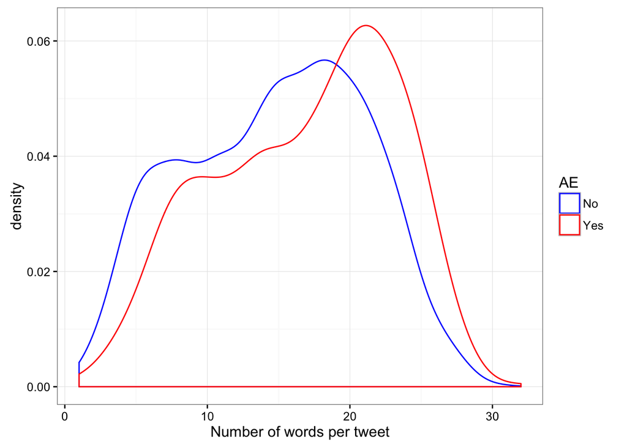

```r
data[[1]] %>%
    unnest_tokens(word, stemmed) %>%
    count(tweet_id, is_AE) %>%
    ggplot(aes(x = n, color = is_AE)) +
    geom_density() +
    xlab("Number of words per tweet") +
    scale_color_manual(values = c("Blue", "Red"),
    name = "AE",
    labels = c("No", "Yes"))
```

## First model: vector space model

We first train a model using the well known vector space model. In this model, the features correspond to **word count** (or other similarly constructed features).

### Document term matrx

The first step consists in preparing the **document term matrix** (DTM). This is a matrix whose columns corresponds to features of the text.

- Each word stem gives a feature, i.e. the feature matrix will have as many columns as there are distinct word stems in the corpus
- The value of each feature for each document (tweet) can be computed in various ways:
- one-hot-encoding: it is one if the word stem is in the tweet, 0 else
- Term frequency: the value of the feature is the number of times the word stem has occured in the tweet
- Term frequency inverse document frequency (*TfIdf*): this is a measure for the relative importance of the feature taking into account the frequency of the word stem in the entire corpus. For example, the word **the** may occur very frequently in a tweet, but it occurs also very often in the corpus. Thus its TfIdf will be low. On the other hand, if a word occurs often within a given tweet, but very rarely in the entire document, this means that the tweet is likely to be about this word and thus it obtains a high TfIdf.

We chose *Term Frequency* here to build the feature vectors. The reason is simple: the other approaches were tried, but using cross validation, Tf performed best.

```r
doc_matrix <- create_matrix(c(data[["train"]]$stemmed,
    data[["test"]]$stemmed),
    language = "english",
    removeNumbers = TRUE,
    removePunctuation = TRUE,
    toLower = TRUE,
    stemWords = TRUE,
    stripWhitespace = TRUE,
    ngramLength = 1,
    minDocFreq = 1,
    weighting = tm::weightTf)
```

### Container

Now that we have a DTM, we could use it directly as a feature matrix and train a model using, e.g. the `caret` package. The package `RTextTools`, however, has a very convenient datastructure allowing us to put all important data into one **container**. The main advantage is that we can keep using sparse matrices as opposed to e.g. the `tidytext` package. In the folowing code chunk, we put the tweets and the outcome in the container, specifying which data are training data and which data are test data. The option `virgin = FALSE` specifies that we have full information about the outcomes on the test data.

```r
container <-
    create_container(doc_matrix,
    c(data[["train"]]$is_AE, data[["test"]]$is_AE),
    trainSize = 1:nrow(data[["train"]]),
    testSize = 1:nrow(data[["test"]]) + nrow(data[["train"]]),
    virgin = FALSE)
```

### Model training

Using the container described above, we can directly train models. Here, we train four different models (training the other models is quite slow and does not significantly improve the performance) using the standard parameters:

- MAXENT: Maximum Entropy
- GLMNET: this is a regularized version of logistic regression
- SVM: regularized support vector machine
- TREE: decision tree

```r
fit_models <-
    train_models(container,
    c("MAXENT", "GLMNET", "SVM", "TREE"),
    cost = 1000)
```

## Model prediction

The `RTextTools` package also allows us to make predictions quite easily. The following code chunk produces the results (i.e. predicted probability and predicted label) for each of the four models on the test set:

```r
preds <- classify_models(container, fit_models)
```

## Model evaluation

The next step is to evaluate the quality of the models. We start with AUC:

```r
par(mfrow = c(2, 2))
    preds %$% roc(data[["test"]]$is_AE, MAXENTROPY_PROB) %>% plot
```

```
##
    ## Call:
    ## roc.default(response = data[["test"]]$is_AE, predictor = MAXENTROPY_PROB)
    ##
    ## Data: MAXENTROPY_PROB in 957 controls (data[["test"]]$is_AE No) > 256 cases (data[["test"]]$is_AE Yes).
    ## Area under the curve: 0.5749
```

```r
preds %$% roc(data[["test"]]$is_AE, GLMNET_PROB) %>% plot
```

```
##
    ## Call:
    ## roc.default(response = data[["test"]]$is_AE, predictor = GLMNET_PROB)
    ##
    ## Data: GLMNET_PROB in 957 controls (data[["test"]]$is_AE No) > 256 cases (data[["test"]]$is_AE Yes).
    ## Area under the curve: 0.8287
```

```r
preds %$% roc(data[["test"]]$is_AE, SVM_PROB) %>% plot
```

```
##
    ## Call:
    ## roc.default(response = data[["test"]]$is_AE, predictor = SVM_PROB)
    ##
    ## Data: SVM_PROB in 957 controls (data[["test"]]$is_AE No) > 256 cases (data[["test"]]$is_AE Yes).
    ## Area under the curve: 0.8038
```

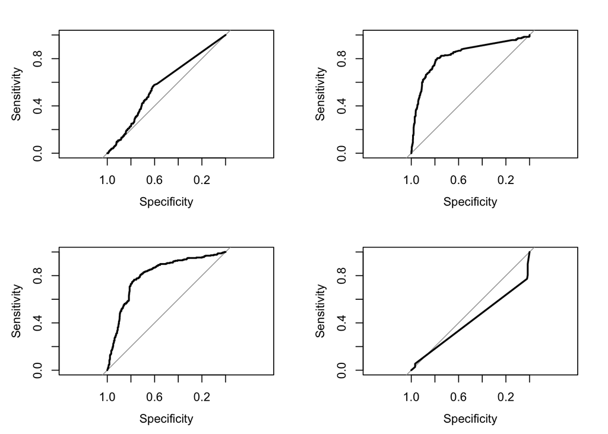

```
##
    ## Call:
    ## roc.default(response = data[["test"]]$is_AE, predictor = TREE_PROB)
    ##
    ## Data: TREE_PROB in 957 controls (data[["test"]]$is_AE No) < 256 cases (data[["test"]]$is_AE Yes).
    ## Area under the curve: 0.4114
```

```r
preds %$% roc(data[["test"]]$is_AE, TREE_PROB) %>% plot
```

We see that the regularized logistic regression performs best with quite a high area under the curve.

Next, the `RTextTools` package allows us to extract important other measures as well quite easily using the `create_analytics` command. This gives us the precision, recall and f-score for each of the models (recall that the f-score is a weighted average of the precision and the recall).

Also it automatically creates an **ensemble summary**. This is a useful statistics about the combined performance of all four models. The line corresponding to, e.g. `n >= 2` means the following:

- Coverage tells us on how many percent of the documents two ore more models agree.
- The recall value corresponds to the recall statistics when restricted to those documents.

```r
analytics <- create_analytics(container, preds)
    summary(analytics)
```

```
## ENSEMBLE SUMMARY
    ##
    ##        n-ENSEMBLE COVERAGE n-ENSEMBLE RECALL
    ## n >= 1                1.00              0.84
    ## n >= 2                1.00              0.84
    ## n >= 3                0.95              0.87
    ## n >= 4                0.78              0.92
    ##
    ##
    ## ALGORITHM PERFORMANCE
    ##
    ##        SVM_PRECISION           SVM_RECALL           SVM_FSCORE
    ##                0.830                0.710                0.745
    ##     GLMNET_PRECISION        GLMNET_RECALL        GLMNET_FSCORE
    ##                0.830                0.640                0.670
    ##       TREE_PRECISION          TREE_RECALL          TREE_FSCORE
    ##                0.860                0.585                0.600
    ## MAXENTROPY_PRECISION    MAXENTROPY_RECALL    MAXENTROPY_FSCORE
    ##                0.745                0.765                0.755
```

From this, it seems quite plausible that stacking these models can make sense.

## Other inputs

One possibility to add additional features to the models, would be to train a second model and use the result of this model as input to a **stacked model**. This ansatz was tried, but it did not lead to improvement in predictive performance.

The “right” way would actually be to simply column bind these new features to the bag of words matrix. This can be done, but it should also be done using sparse matrices, otherwise, we have to reduce the dimension of the bag of words matrix (i.e. use fewert words as features). This is why we did not use the `tidytext` package here (it was tried, but the performance is worse if the number of terms is restricted).

Here, we just outline how a second model can be trained: we do basic preprocessing. Here, we compute the sentiments by using the dataset from the `tidytext` package.

```r
preprocess_second <- function(my_data) {
    sentiments_tweets <-
    my_data %>%
    unnest_tokens(word, stemmed) %>%
    left_join(sentiments %>% mutate(word = stemDocument(word)),
    by = "word") %>%
    count(tweet_id, sentiment) %>%
    mutate(sentiment = str_c("sentiment_", sentiment)) %>%
    filter(!is.na(sentiment)) %>%
    spread(sentiment, n, fill = 0)

    res <- left_join(my_data %>% select(tweet_id),
    sentiments_tweets,
    by = "tweet_id")

    res[is.na(res)] <- 0

    left_join(my_data, res, by = "tweet_id") %>%
    mutate(tweet_length = str_length(stemmed))

    }

    train_2nd <- preprocess_second(data[[1]])
    cv_2nd <- preprocess_second(data[[2]])
```

```r
fit_2nd <- train(is_AE ~ .,
    data = train_2nd %>% select(starts_with("sentiment"),
    tweet_length,
    is_AE),
    trControl = trainControl(method = "cv",
    number = 5,
    p = 0.75),
    method = "rf")

    par(mfrow = c(1, 1))
    preds$model_two <- predict(fit_2nd, newdata = cv_2nd, type = "prob")[, 2]
    fit_2nd
```

```
## Random Forest
    ##
    ## 3304 samples
    ##   11 predictor
    ##    2 classes: 'No', 'Yes'
    ##
    ## No pre-processing
    ## Resampling: Cross-Validated (5 fold)
    ## Summary of sample sizes: 2643, 2643, 2644, 2643, 2643
    ## Resampling results across tuning parameters:
    ##
    ##   mtry  Accuracy   Kappa
    ##    2    0.8105327  0.05768651
    ##    6    0.8065942  0.09380786
    ##   11    0.8002411  0.09719245
    ##
    ## Accuracy was used to select the optimal model using  the largest value.
    ## The final value used for the model was mtry = 2.
```

```r
varImp(fit_2nd)
```

```
## rf variable importance
    ##
    ##                        Overall
    ## tweet_length           100.000
    ## sentiment_negative      69.725
    ## sentiment_positive      48.814
    ## sentiment_sadness       22.418
    ## sentiment_fear          14.322
    ## sentiment_anticipation  11.219
    ## sentiment_disgust        9.499
    ## sentiment_trust          9.094
    ## sentiment_anger          7.912
    ## sentiment_joy            3.171
    ## sentiment_surprise       0.000
```

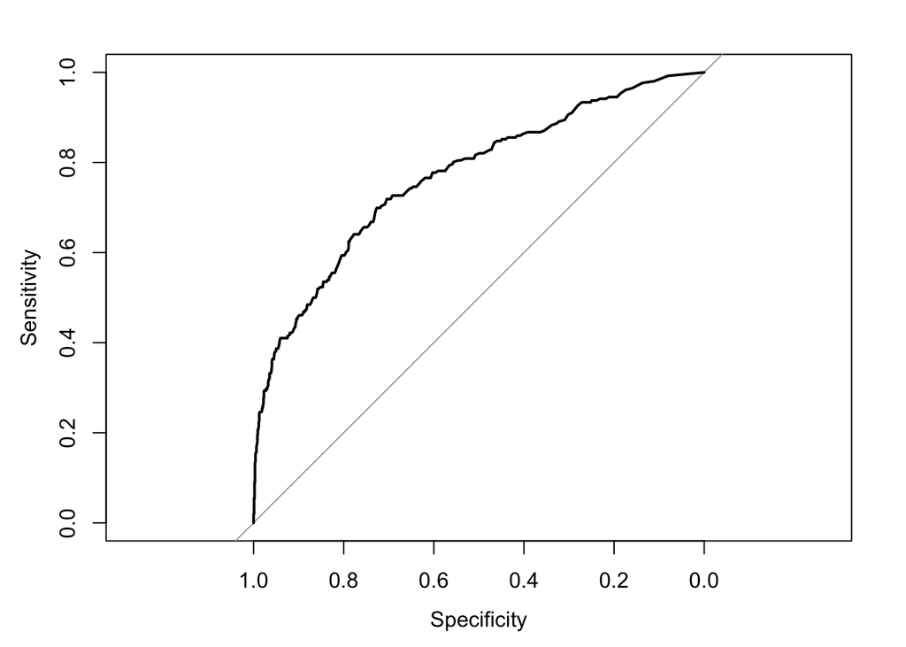

```
##
    ## Call:
    ## roc.default(response = cv_2nd$is_AE, predictor = preds$model_two)
    ##
    ## Data: preds$model_two in 957 controls (cv_2nd$is_AE No) < 256 cases (cv_2nd$is_AE Yes).
    ## Area under the curve: 0.7688
```

```r
pROC::roc(cv_2nd$is_AE, preds$model_two) %>% plot
```

As we saw in the exploratory part of the analysis, `tweet_length` is a good predictor, as well as the positive and negative sentiments.

The area under curve is actually quite good for a model with so few features (just think what we did in terms of dimension reduction: we reduced from roughly 8000 dimensions to roughly 10 dimensions with relatively little reduction in predictive performance!)

## Aggregating predictions:

The next step is to aggregate the predictions from different models into a final model. We use the outputs from the previous models as inputs and train a random forest.

```r
preds$results <- data[["test"]]$is_AE
    tr_control <- trainControl(method = "cv",
    number = 10,
    summaryFunction = twoClassSummary,
    classProbs = TRUE)

    tune_grid <- expand.grid(mtry = c(1, 2, 3, 4))

    fit_rf <- train(results ~ MAXENTROPY_PROB + GLMNET_PROB + SVM_PROB +
    TREE_PROB + model_two,
    data = preds,
    method = "rf",
    trControl = tr_control,
    tuneGrid = tune_grid,
    metric = "ROC"
    )
```

We look at the results:

```r
fit_rf
```

```
## Random Forest
    ##
    ## 1213 samples
    ##    9 predictor
    ##    2 classes: 'No', 'Yes'
    ##
    ## No pre-processing
    ## Resampling: Cross-Validated (10 fold)
    ## Summary of sample sizes: 1092, 1091, 1091, 1092, 1091, 1092, ...
    ## Resampling results across tuning parameters:
    ##
    ##   mtry  ROC        Sens       Spec
    ##   1     0.8786505  0.9467325  0.5390769
    ##   2     0.8674475  0.9351864  0.5621538
    ##   3     0.8646395  0.9278947  0.5660000
    ##   4     0.8637978  0.9257785  0.5584615
    ##
    ## ROC was used to select the optimal model using  the largest value.
    ## The final value used for the model was mtry = 1.
```

```r
varImp(fit_rf)
```

```
## rf variable importance
    ##
    ##                  Overall
    ## GLMNET_PROB     100.0000
    ## SVM_PROB         72.5722
    ## model_two        62.0681
    ## TREE_PROB         0.2203
    ## MAXENTROPY_PROB   0.0000
```

# Recent data

The next step consists in checking whether we can reproduce these results with recently collected twitter data. We decided to focus on the bag of words model.

In order for the following code chunk to work, this [hack](https://groups.google.com/forum/embed/#!topic/rtexttools-help/Drqr3Z897Mk) has to be performed.

We plot the receiver-operating characteristic for the new tweets.

```r
source("../r/clean_tweets.R")
    source("../r/make_drug_list.R")
    source("../r/make_slang_lookup.R")
    source("../r/helper_functions/create_matrix_fixed.R")

    cleaned_tweet <-
    read.xlsx("../data/download_tweets/tweets_recent_annotated.xlsx",
    sheetIndex = 1) %>%
    select(tweet_id, tweet_text, is_AE) %>%
    clean_tweets(make_drug_list(), make_slang_lookup())


    source("../r/helper_functions/create_matrix_fixed.R")
    new_tweets_dtm <-
    create_matrix(cleaned_tweet$stemmed,
    originalMatrix = doc_matrix,
    language = "english",
    removeNumbers = TRUE,
    removePunctuation = TRUE,
    toLower = TRUE,
    stemWords = TRUE,
    stripWhitespace = TRUE,
    ngramLength = 1,
    minDocFreq = 1,
    weighting = tm::weightTf)

    new_container <- create_container(new_tweets_dtm,
    labels = c(data[[1]]$is_AE, data[[2]]$is_AE,
    cleaned_tweet$is_AE),
    trainSize = NULL,
    testSize = 1:nrow(cleaned_tweet),
    virgin = FALSE
    )

    preds_new <- classify_models(new_container, fit_models)


    # Sentiment model
    cleaned_tweet_two <- cleaned_tweet %>% preprocess_second

    # Add sentiment variables not in data frame
    all_sentiments <-
    sentiments %$%
    sentiment %>%
    keep(~!is.na(.)) %>%
    unique %>%
    map_chr(~str_c("sentiment_", .))

    sentiments_not_present <-
    keep(all_sentiments, ~(!. %in% colnames(cleaned_tweet_two)))

    cleaned_tweet_two[, sentiments_not_present] <- 0

    # Predict second model
    preds_new$model_two <-
    predict(fit_2nd, cleaned_tweet_two, type = "prob")[, 2]

    analytics <- create_analytics(new_container, preds_new)
    print(summary(analytics))
```

```
## ENSEMBLE SUMMARY
    ##
    ##        n-ENSEMBLE COVERAGE n-ENSEMBLE RECALL
    ## n >= 1                1.00              0.50
    ## n >= 2                1.00              0.50
    ## n >= 3                0.99              0.50
    ## n >= 4                0.82              0.47
    ##
    ##
    ## ALGORITHM PERFORMANCE
    ##
    ##        SVM_PRECISION           SVM_RECALL           SVM_FSCORE
    ##                0.505                0.500                0.375
    ##     GLMNET_PRECISION        GLMNET_RECALL        GLMNET_FSCORE
    ##                0.520                0.505                0.390
    ##       TREE_PRECISION          TREE_RECALL          TREE_FSCORE
    ##                0.425                0.490                0.345
    ## MAXENTROPY_PRECISION    MAXENTROPY_RECALL    MAXENTROPY_FSCORE
    ##                0.470                0.480                0.415
    ##        SVM_PRECISION           SVM_RECALL           SVM_FSCORE
    ##                0.505                0.500                0.375
    ##     GLMNET_PRECISION        GLMNET_RECALL        GLMNET_FSCORE
    ##                0.520                0.505                0.390
    ##       TREE_PRECISION          TREE_RECALL          TREE_FSCORE
    ##                0.425                0.490                0.345
    ## MAXENTROPY_PRECISION    MAXENTROPY_RECALL    MAXENTROPY_FSCORE
    ##                0.470                0.480                0.415
```

```r
par(mfrow = c(1, 2))
    preds_new %$% pROC::roc(cleaned_tweet$is_AE, GLMNET_PROB) %>% plot
```

```
##
    ## Call:
    ## roc.default(response = cleaned_tweet$is_AE, predictor = GLMNET_PROB)
    ##
    ## Data: GLMNET_PROB in 319 controls (cleaned_tweet$is_AE 0) > 76 cases (cleaned_tweet$is_AE 1).
    ## Area under the curve: 0.6876
```

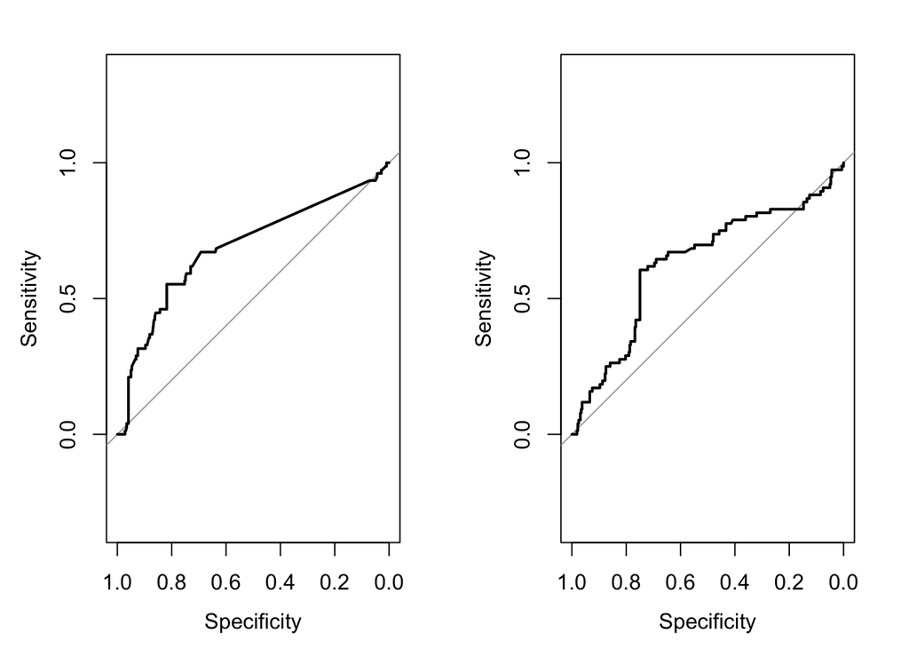

```
##
    ## Call:
    ## roc.default(response = cleaned_tweet$is_AE, predictor = SVM_PROB)
    ##
    ## Data: SVM_PROB in 319 controls (cleaned_tweet$is_AE 0) > 76 cases (cleaned_tweet$is_AE 1).
    ## Area under the curve: 0.6327
```

```r
preds_new %$% pROC::roc(cleaned_tweet$is_AE, SVM_PROB) %>% plot
```

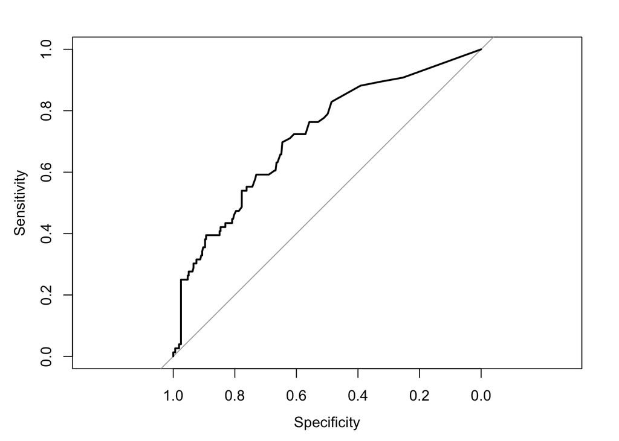

```
##
    ## Call:
    ## roc.default(response = cleaned_tweet$is_AE, predictor = preds_new_final)
    ##
    ## Data: preds_new_final in 319 controls (cleaned_tweet$is_AE 0) < 76 cases (cleaned_tweet$is_AE 1).
    ## Area under the curve: 0.7169
```

```r
par(mfrow = c(1, 1))
    preds_new_final <- predict(fit_rf, preds_new, type = "prob")[, 2]
    pROC::roc(cleaned_tweet$is_AE, preds_new_final) %>%
    plot()
```

We see that the result is quite a bit worse, but still much better than random. In particular, the support vector machine had a huge drop in performace.

A very likely reason is that our way of manually annotating tweets is different from the researchers in [here](http://diego.asu.edu/Publications/ADRMine.html) and [here](http://diego.asu.edu/downloads/twitter_annotated_corpus/): they had meetings with experts that went very carefully over all tweets. On the other hand, it is not even clear how good our area under curve as annotators would be.

## Save models

```r
save(fit_models, file = "../data/models/fit_models.RData")
    save(fit_rf, file = "../data/models/stacked_rf.RData")
    save(doc_matrix, file = "../data/models/doc_matrix.RData")
    save(data, file = "../data/models/train_data.RData")
    save(fit_2nd, file = "../data/models/sentiment_model.RData")
```

Comorbidity